# 环境数据的阈值探索

2014/12/12

## 环境化学中的阈值

> **对象发生某种变化所需的某种条件的值**
- 条件：环境样品中污染物浓度
- 对象
  - 物化性质：K<sub>ow</sub>、K<sub>oa</sub>等分子描述符
  - 环境因子：温度、气压、海拔
  - 毒性：剂量－效应关系、毒物兴奋效应
  - 健康：疾病发病率、死亡率

> **环境阈值是研究环境过程机理或风险评估的关键参数**

## 阈值常见判断方法

- 拟合方程
  - ED50 四参数法
  - 本质上拟合不同形式的 logistic 模型
- 曲棍球模型
  - 分段线性模型
  - 贝叶斯方法(MCMC)
- 问题：不够直观

## 单变量案例：普吉特海湾PCBs开放数据

- 数据来自美国环保署[网站](http://www.epa.gov/pugetsound/bold.html)
- 75个底泥样品采样点数据与污染物浓度数据

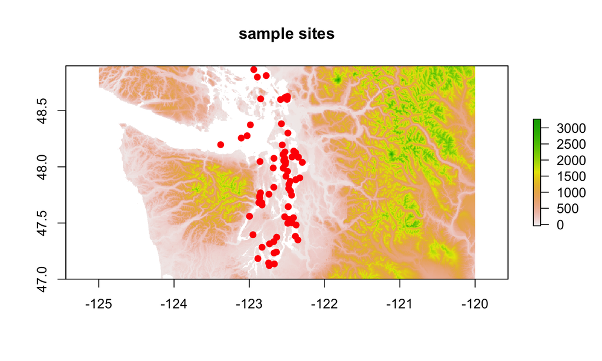

## PCBs与采样深度的关系：线性回归与LOWESS回归

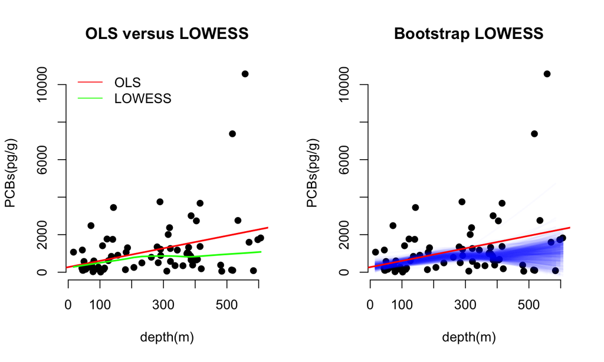

## PCBs与采样深度的关系

- 线性回归与LOWESS
  - R<sup>2</sup>: 0.1294121 P值: 0.0015247
  - lowess回归对异常值稳健，够直观，但不易描述
- 自举重采样
  - 有放回重采样1000次
  - 拟合1000条LOWESS回归线 透明度1%
  - 根据颜色从图上读出阈值

## 多变量问题：决策树

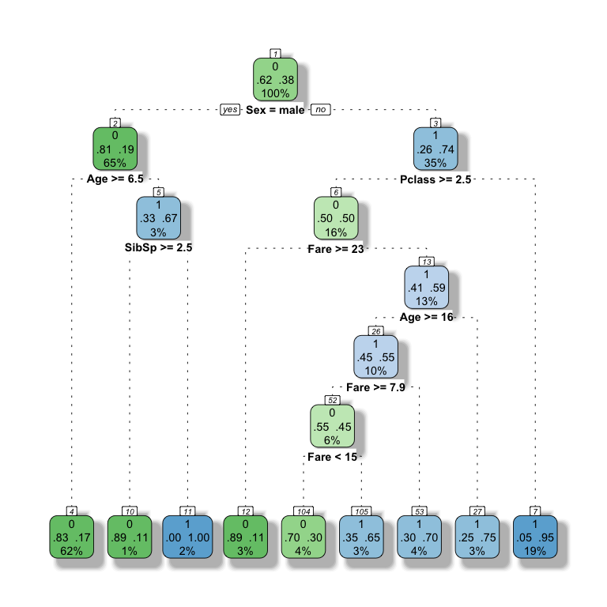

- 数据结构探索
- 越靠近根 分异最大
- 可用来筛选可疑变量及其阈值

## 多变量案例：寻找影响分子沸点的拓扑描述符

- 出发点：结构影响性质
- 分子描述符可大量获得
- 多元线性回归无法进行机理探讨
- 特定描述符的阈值分割有助于机理讨论
- 277个分子 120个拓扑描述符 探讨其对沸点的影响

## 结果展示

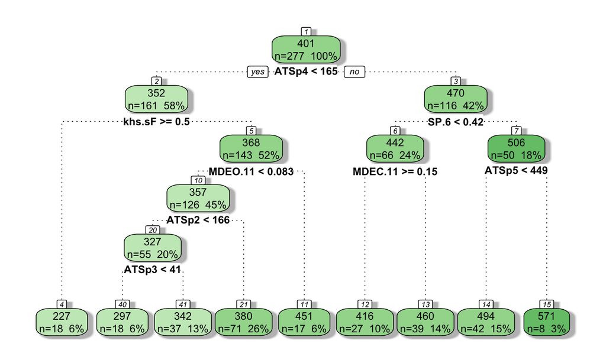

## 阈值探索小结

- 让数据说话，不依赖预设分布或动力学假设
- 基于探索发现‘疑似’规律并建模
- **强规律**会再现于任一个模型

[figure not shown]

## THANK YOU

- [Bootstrap入门](http://www.ats.ucla.edu/stat/r/library/bootstrap.htm)
- [曲棍球模型](http://cran.r-project.org/web/packages/segmented/index.html)
- [决策树变量筛选](http://www.baylor.edu/content/services/document.php?id=46132)
- [QSPR入门](https://en.wikipedia.org/wiki/Quantitative_structure%E2%80%93activity_relationship)
- [TOX21 challenge](https://tripod.nih.gov/tox21/challenge/)
- [可复算性研究简介](http://blog.sciencenet.cn/blog-430956-813992.html)
- [幻灯片源码](https://github.com/yufree/presentation/blob/master/threshold/threshold.Rmd)
- yufreecas@gmail.com

[figure not shown]